# Final Project Progress Report

Elsie Basa - Student ID: 914022828

3/9/2023

# 1 Abstract

An experiment by Steinmetz conducted in 2019 studied the effect of stimuli on mice and measure there feedback response and neuron firings. 39 session with several hundreds of trails in each were conducted and in this report sessions 1-5 are studied. In sessions 1-3 Cori the mouse was research subject and for sessions 4 and 5 Forssmann was the research subject. To conduct the experiment visual imaging using two screens, one on the left side and one on the right side of the mice. This was measure as left and right contrasts which have 4 different level (0,0.25,0.5, 1) with 0 being no absence of contrast. During the experiment the mice’s feed back was recorded using a device controlled by the mice’s front paws. This report evaluate the mean firing rate with trial being the basic unit of analysis. It was found that there was an interaction between left contrast and right contrast which suggest that both sides of the brain interact when shown visual stimuli. A model fitted with max firing rate was considered however its deviations from normality were much more severe so the mean firing rate model was preferred. It was evident that there were difference in mean firing rate across session having session a random variable was used to contain this in the model.

A logistic regression model was utilized to predict each trial’s outcome using a predictive modeling strategy. The model was able to detect the majority of true positives but created a false positive 50% of the time.The specificity and sensitivity values of were approximately 50% and 76%, respectively.

# 2 Introduction

An experiment conducted by Steinmetz et al. (2019) aimed to study the effect of stimuli on mice. In the experiment many hundreds of trials were carried out on 10 mice over 39 sessions.

In this experiment, visual stimuli were shown to each mouse at random on two screens, one on the left side and one on the right side. The stimuli were presented at various levels, with values of {0, 0.25, 0.5, 1}, with 0 indicating the absence of stimuli and 1 indicating the highest intensity of stimuli. Following that, the mice’s response were captured using a motorized wheel operated by the mice’s forepaws. The feed back response took values of 1 and -1, with 1 being the mouse responded to the stimuli and -1 when the mouse did not respond to the stimuli. During the experiment data was collected on the activity of the neuron within the mice’s visual cortex and recorded as spike trains. The spike trains consisted of a series of ordered neuronal firing events.

This project only uses a subset of the data, sessions 1 through 5 from two mice, Cori and Forssmann Cori was used in session 1-3 and Forssmann was used in session 4 and 5. Moreover, to collapse the neuron dimension from 2 dimensions into one dimension the mean firing rate was used. To do this the number of spikes will be summed up and divided by the number of neurons then the 0.4, how long after offset the the spike trains were examined. Hence why 0.4 will be used when calculating the mean firing rate. This is due to the fact that mean firing rate is what is typically used in other neural science analysis according to Cambridge University Press. The max firing rate was considered due to the fact that not all neurons fired and a different amount of neurons fired during each session.

The question of interest in this projects are:

1.How do neurons in the visual cortex respond to the stimuli presented on the left and right?

2.How to predict the outcome of each trial using the neural activities and stimuli?

# 3 Background

In this study conducted by Steinmetz et al. (2019), experiments on 10 mice over 39 session were conducted over hundreds of trials. In this experiment visual stimuli were presented at random to each of the mice on two screens, positioned on the left and right sides. The stimuli were presented at different intensity levels which took values of {0, 0.25, 0.5, 1}, with 0 indicating the absence of a stimuli and 1 being the highest intensity of stimuli. The mice were required response to the stimuli by performing decision-making task using a motorized whee controlled by the mice’s forepaws. Following the mice’s repose, they were provided with either a reward or penalty. During, the task, data was collected on the activity of neurons within the mice’s visual cortex was recorded and subsequently and made available as spike trains. These spike train represented the sequence of neuron firings.

This project aims to examine the spike trains of neurons located in the visual cortex ranging from stimulus onset to 0.4 seconds post-onset. We have chosen to limit our analysis to a subset of data and use only five experimental sessions (Sessions 1 to 5) from two mice (Cori and Forssmann).

# 4 Descriptive analysis

#### 4.0.0.1 Graphical Analysis

A Scatter plot between Contrast Left and Contrast Right levels by session and feedback type demonstrated that mice when there was no contrast for both levels that both mice tend to respond correctly. However it is evident as the sessions continued, there was an increase in an incorrect feedback type despite there being no contrast on either side. The the contrast levels were equal such as both contrast left and contrast right being 0.5 showed that half the time the mouse was answering successfully and the other half unsuccessfully.

When the left contrast level compared to the right level was higher the feed back response tended to be more successful. However, for the opposite the feed back was less successful.

It is evident that as time went on the mice there was an increase in unsuccessful feed back.

Overall, this evidence suggest that making session number a random variable will help contain some of these notable differences between each session.

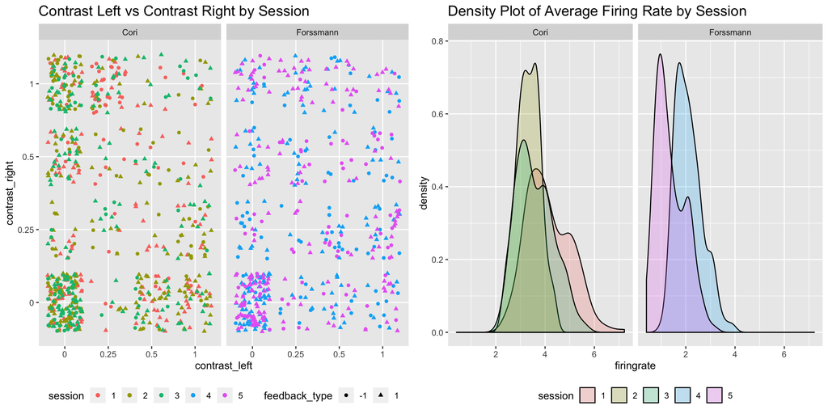

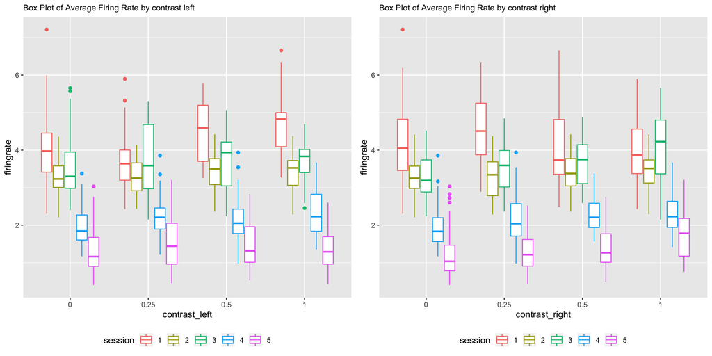

|  | session: 1 (N = 214) | session: 2 (N = 251) | session: 3 (N = 228) | session: 4 (N = 249) | session: 5 (N = 254) |
| --- | --- | --- | --- | --- | --- |
| **Average Firing Rate by Session** |  |  |  |  |  |
| min: | 2.3033708 | 2.2091932 | 2.1491228 | 0.9791667 | 0.4040404 |
| max: | 7.219101 | 4.423077 | 5.657895 | 3.937500 | 3.207071 |
| mean (sd) | 4.14 ± 0.89 | 3.33 ± 0.48 | 3.59 ± 0.74 | 2.12 ± 0.55 | 1.38 ± 0.60 |
| median (IQR) | 3.99 (3.41, 4.85) | 3.34 (3.00, 3.69) | 3.45 (3.03, 4.09) | 2.04 (1.69, 2.44) | 1.24 (0.91, 1.86) |

# 5 Inferential analysis

A mixed effect model was created with the fixed variables contrast left, contrast right, the interaction between contrast left and right, and a random variable of session number.

The regression equations (index: i =1…4, j = 1…4, k = 1,..5):
$$Y_{ijkl} = \mu_{...}+\alpha_i+\beta_j+(\alpha\beta)_{ij}+\gamma_k+\epsilon_{ijkl}\space$$

In this equation $Y_{ijkl}$ represent the lth trail in the ith left contrast level and jth right contrast level at the kth session $\mu$ represents the population mean $\alpha_i$ represents the added effect from contrast left $\beta_j$ represents the added effect from contrast right $\alpha\beta)_{ij}$ represents the added effect from interaction between contrast left and contrast right $\gamma_k$ represents the random effect from session $\epsilon_{ijkl}$ represents the error terms which are mutually independent

The following constraints of the model are:
$$\sum_i^n\alpha_i = 0\quad,\sum_i^n\beta_j = 0\space \quad, \sum_{j=1}^b (\alpha\beta)_{ij} =\sum_{i=1}^a (\alpha\beta)_{ij} =0 \space\space \forall i,j\quad \gamma_ {\mathrm{k}} \sim \mathrm{N}\left(0, \sigma_\gamma^2\right)$$

In this model, there are several fixed effect coefficients in this model and due to the great amount of them they will not be added to the report. The random effect from each of the session will be evaluated

Random Intercepts from Session

| Session | Random Intercept |
| --- | --- |
| 1 | 1.213 |
| 2 | 0.404 |
| 3 | 0.695 |
| 4 | -0.790 |
| 5 | -1.522 |

This shows that session 1 a higher mean firing rate of 1.213 from the random effect from that session. Session 2 a higher mean firing rate of 0.404 from the random effect from that session. Session 3 had an increase in mean firing rate of 0.695 from the random effect from that session. Session 4 and 5 had a decrease in mean firing rate of -0.79 and -1.522 respectively, from the random effect from those sessions.

To test the hypothesis that the interaction term is relevant in the model the likelihood ratio test was conducted.

$$H_o: (\alpha\beta)_{ij} = 0 \space\space for \space i = 1,..4 \space and \space j = 1,..4 \quad vs \quad H_a:\space \text{not all} \space (\alpha\beta)_{ij} = \space are \space 0$$

The p-value of the test is 0.04112 <0.05 which means that the interaction term is significant at the 0.05 significance level.

# 6 Sensitivity analysis

#### 6.0.0.1 Model Diagnostics

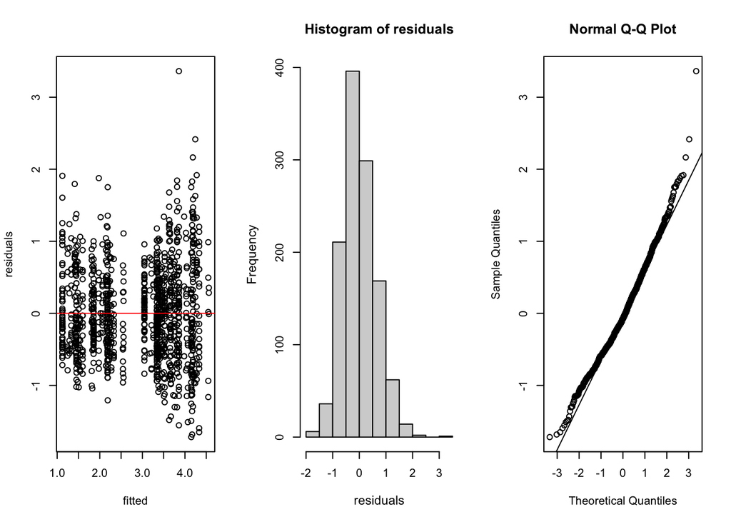

The Shapiro wilks test is used to test for normality. The p-value of the test is less than 0.05 which means that the assumption of normality does not hold at the 0.05 significance level

Furthermore, the Levenes test was used to test for equal variance at the 0.05 significance level. The p-value for contrast left was less than 0.05. Also the p-values for contrast right and the interaction term were both great than 0.05. The Levenes test suggest that the variance of the error terms are equal for th contrast right and the interaction term but not contrast left.

For that reason, our assumption of homogeneity of the error terms holds for contrast right and the interaction term but the assumption of normality does not hold however it is not a severe deviation.

#### 6.0.0.2 Alternative Model Fitting

##### 6.0.0.2.1 Fixed Effect Model

Furthermore, a fixed effect model was considered where the variables, contrast left, contrast right, the interaction term and session, were used and kept ed fixed.

A likelihood ratio test was conducted at the 0.05 significance level to see if using session as a random variable was significant. The p-value of the test was 4.362e-08 which is less than 0.05 therefore we reject the null hypothesis meaning there is significant evidence to conclude that having session as a random variable is significant to the model.

##### 6.0.0.2.2 Maximum Firing Rate Model

Additionally, a mixed effect model fitting maximum firing rate was considered instead of mean firing rate. The reasoning behind this is that since not all neurons fire and there area different number of neurons that a max firing rate can help contain this.

Looking at the model diagnostics the QQ- Plot is much more heavy tailed then the the model with mean firing rate. The residual vs fitted plot also shows evident correlation between the two. Thus making the maximum firing mode rate less ideal then the mean firing rate.

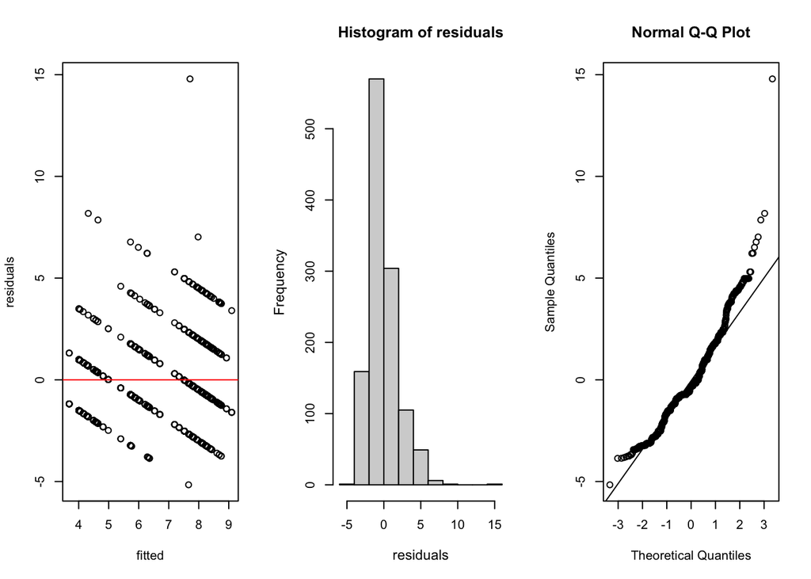

# 7 Predictive modeling

Using a logit regression with feedback as the dependent variable and mean firing rate,contrast left, contrast right, the interaction term and session as the x variables. When creating the logistic model the interaction term was tested at the 0.05 significance level. The interaction term was deemed significant in the model thus meaning it should be kept in the logistic regression model.

To choose a model the AIC criteria was used. The model that contained mean firing rate,contrast left, contrast right, the interaction term and session has an aic of 1323.7726037. On the other hand the model exuding session had an aic of 1380.0545345 . The model including session was chosen since it has a lower AIC value and therefore is a better fit.

The logistic regression equation:

$$logit(\pi(y)) = \beta_0 + \beta_1X_1+\sum_{i=1}^4\beta_2X_{2i}+\sum_{j=1}^4\beta_3X_{3j}+ \sum_{k=1}^5 (\beta_4X_{4k})+ \sum_{i=1}^4 \sum_{j=1}^4 (\beta_5X_{2i}X_{3j})$$

In this equation $\beta_0$ represents the y intercept.$\beta_1$ is the added effect from mean firing rate. $\beta_2$ and $\beta_3$ represent the added effect from left contrast and right contrast respectively. The i and j indexi represent the 4 contrast levels i=1 or j=1 is contrast level 0,i=2 or j =2 is contrast level 0.25,i=3 or j =3 is contrast level 0.5, and i=4 or j =4 is contrast level 1.$\beta_4$ represents the added effect of session. The index k represent session 1 through 5. $\beta_5$ represents the added effect from the interaction between left contrast and right contrast.

$X_1$ represents the variable mean firing rate, $X_2$ represents the variable left contrast, $X_3$ represents the variable right contrast, $X_4$ represents the variable session.

Furthermore, the logistic regression model will be trained and used to predict the outcome of each trial.

To split the data for training, the first 100 trials from session 1 will be removed from the training data set. The rest of the data set will be used for training the model. The first 100 trails from session 1 will be used to evaluate the predicative model’s performance using sensitivity and specificity analysis.

In order to train the data, a threshold value of 0.71 was chosen since it is the area under the ROC curve.

The sensitivity is 75.68% and the specificity is 50%

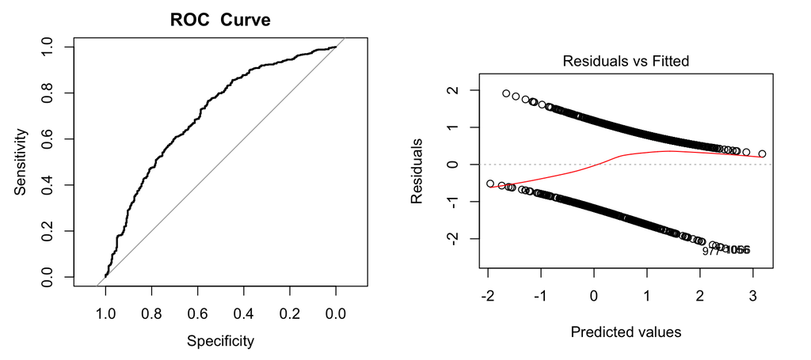

The matrix shows the predicted value vs the actual values

$$\begin{array}{l | r l}
\hline
& actual & values\\
\hline
& & -1 & 1\\
\hline
predicted & -1 & 13 & 18\\
\hline
values& 1 & 13 & 56\\
\hline
\end{array}$$

# 8 Discussion

The anova model showed that effects of the left contrast and right contrast aren’t simply additive but rather there is an interaction between the two. This suggest that both sides of the brain interact.

A max firing rate model was considered but had severe deviations from normality compared to mean firing rate therefore the mean firing rate model was preferred. Mean firing rate is also something that is used in a lot of neuron firing experiments as noted by Cambridge University.

Additionally, predicative modeling was used to try to predict the outcome of each trial. This was done using a logistic regression. The model used all trials except the first 100 trials of session 1 to train. Those were used to analyze the specificity and sensitivity of the model. This model used mean firing rate,left contrast, right contrast, the interaction between the two contrast and session to predict feedback type. The specificity and sensitivity were evaluated on the 100 trials from session 1. The model had a specificity of about 50% meaning the model meaning half the time the model produced a false positive. The sensitivity was about 76% meaning that the model was able to decently pick out most of the true positive cases.

Some caveats on the current analysis is that due that the there is some deviations from normality when using the mean firing rate. A max firing rate was considered however since the deviations from normality were much more severe then when using the mean firing rate.  
Based off the model diagnostic the deviations from normality are not severe for mean firing rate. Another caveat was that the number neurons that fired were different among each session which suggest that some neurons didn’t fire during the tests.

Some real world applicaton is understanding how the neurons in the brain react to stimuli. Also understanding how both sides of the brain interact with each other when exposed to visual stimuli. This test can possibly be replicated on other species to see if the results are similar.

# 9 Reference

Steinmetz, N.A., Zatka-Haas, P., Carandini, M. et al. Distributed coding of choice, action and engagement across the mouse brain. Nature 576, 266–273 (2019). https://doi.org/10.1038/s41586-019-178

Cambridge University Press.https://neuronaldynamics.epfl.ch/online/Ch7.S2.html#:~:text=The%20firing%20rate%20in%20trial,k%3DnspkT.&text=The%20length%20T%20of%20the,of%20neuron%20and%20the%20stimulus.